# Principal Component Analysis - Bank Customers Perception

## Principal Component Analysis - What is it?

**Principal Component Analysis (PCA) is a statistical technique that reduces a large set of variables into a smaller number of latent dimensions known as principal components.** These new dimensions capture most of the variability present in the original data, allowing complex structures to be simplified without losing essential information. In practical terms, PCA transforms dozens of highly correlated attributes into a few interpretable axes, making it easier to visualize relationships, detect patterns, and compare elements such as brands, segments, or products.

**In market research, PCA is especially valuable for identifying the perceptual drivers that shape how consumers differentiate between brands.** Using numerous perception items—such as quality, innovation, trust, customer service, or value—PCA enables the creation of perceptual maps where brands are projected onto a reduced space, revealing similarities, competitive clusters, and white-space opportunities. This simplified representation helps teams understand competitive positioning, explore brand groupings, and communicate insights in a clear, visual, and strategic way to business, marketing, and product stakeholders.

## Dataset and Survey Example

Source: https://data.mendeley.com/datasets/4wyg7vdzzm/3

**Survey data on corporate reputation, relational trust, satisfaction, and loyalty (n=675) as perceived by customers of German banks.**

The original survey dataset did not include information about respondents’ main bank. For exploratory and methodological purposes, a synthetic categorical variable is generated with 18 bank options, randomly assigned across respondents (n = 675).

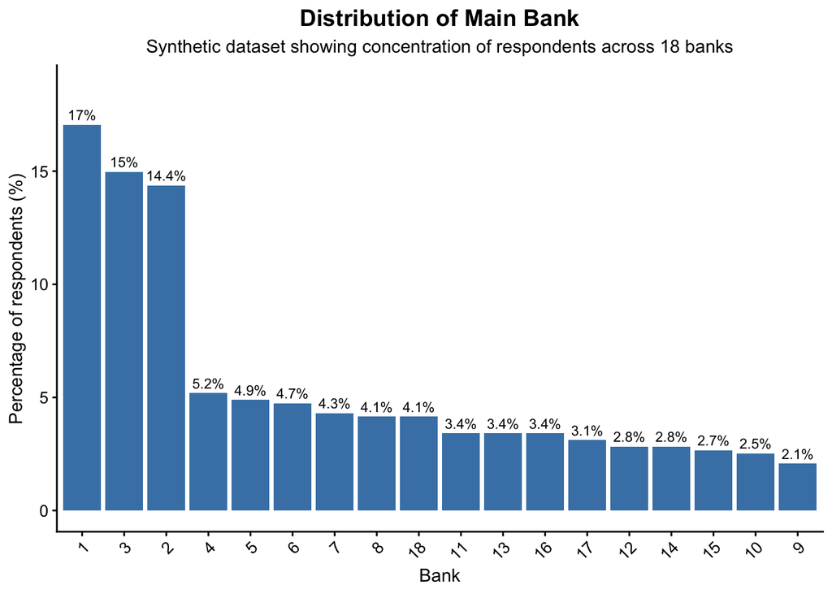

## PCA model

PCA Summary Table

Standard deviation, proportion of variance, and cumulative variance (Top 10 PCs)

| Component | Std_Dev | Prop_Variance | Cum_Variance |
| --- | --- | --- | --- |
| PC1 | 4.5184632 | 0.5833 | 0.5833 |
| PC2 | 1.2317155 | 0.0433 | 0.6267 |
| PC3 | 1.1769043 | 0.0396 | 0.6662 |
| PC4 | 1.0103577 | 0.0292 | 0.6954 |
| PC5 | 0.9431970 | 0.0254 | 0.7208 |
| PC6 | 0.8959470 | 0.0229 | 0.7438 |
| PC7 | 0.8735807 | 0.0218 | 0.7656 |
| PC8 | 0.8146846 | 0.0190 | 0.7845 |
| PC9 | 0.7698947 | 0.0169 | 0.8015 |
| PC10 | 0.7506631 | 0.0161 | 0.8176 |

The first principal component explains 58% of the total variance, indicating a strong general perception dimension underlying customer evaluations. The second and third components explain an additional 4% and 3.9%, Together, the first two components account for 63% of total variance, which is sufficient for building a 2-dimensional perceptual map.

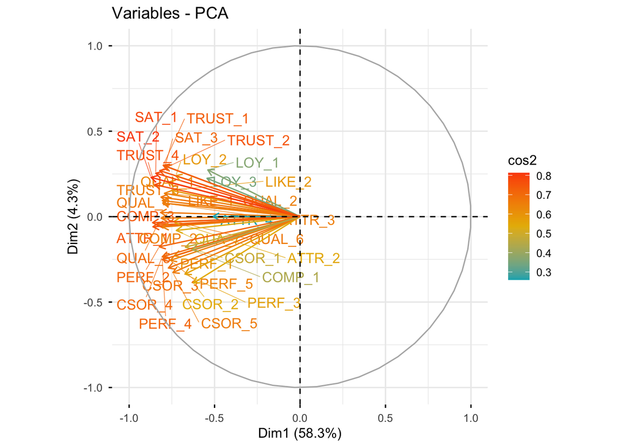

**The PCA variable map displays how each attribute contributes to the underlying perceptual dimensions by representing them as vectors in a two-dimensional space.** The length of each vector reflects its importance in defining the components, while the direction indicates how strongly it aligns with each axis. Attributes pointing in similar directions share strong correlations, whereas those forming large angles represent distinct or uncorrelated dimensions. By examining the overall configuration of vectors, it becomes possible to understand which groups of attributes define each principal component and how the perceptual structure of the dataset is organized.

The PCA variable map shows how the different attributes relate to the two main dimensions found in the data. **The first dimension (PC1) is shown on the horizontal axis and represents a general evaluation of the bank.** Almost all arrows point in the same direction along this axis, which means that customers tend to rate most aspects of their bank in a similar way: when they think highly of one aspect, they also think highly of the others.

**The second dimension (PC2), shown on the vertical axis, captures a smaller difference between groups of attributes.** Some variables appear slightly above the horizontal line, meaning they are more related to trust and satisfaction. Others appear slightly below, meaning they are more related to social responsibility or performance. Even though this separation is subtle, it shows that customers make a secondary distinction between relational aspects (such as trust) and more functional or institutional aspects (such as responsibility and performance).

### Biplot

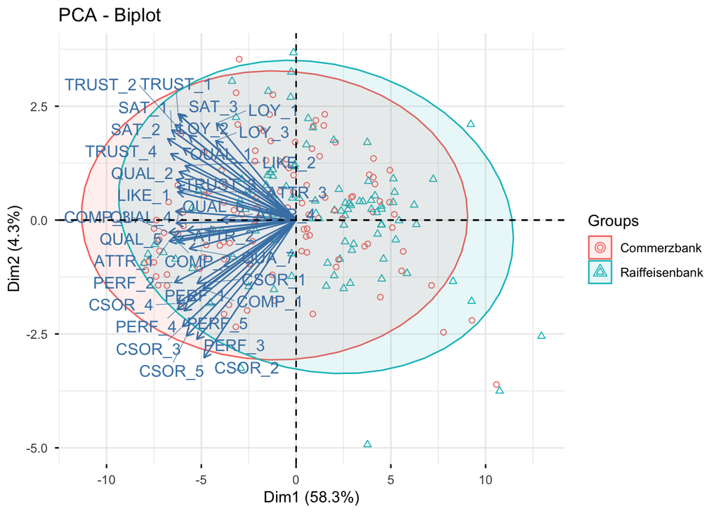

**This biplot shows how the selected banks are positioned in relation to the key perceptual attributes identified by the PCA.** The arrows represent the direction and strength of each attribute in the two main perceptual dimensions, while each point reflects the distribution of customer responses for the chosen banks. Banks located closer to a given arrow are more strongly associated with that attribute. By comparing the relative position of the two banks within this space, it becomes possible to see which attributes differentiate them and which ones they share. This visualization therefore highlights meaningful perceptual contrasts between the selected brands based on customer evaluations.

Please note that the *main_bank* variable is synthetic, so the positions shown in the plot do not represent real customer responses or actual market data.

### Perceptual Map of Banks

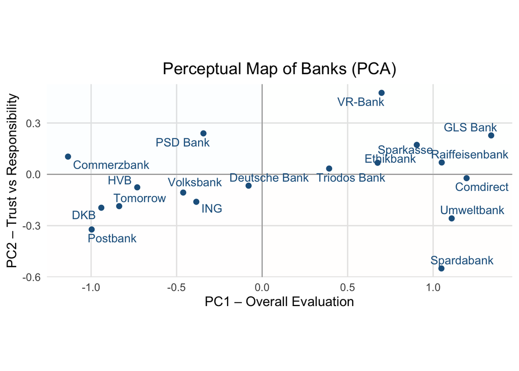

**This perceptual map shows how each bank is positioned across the two main dimensions identified by the PCA.** The horizontal axis (PC1) represents the overall evaluation of the bank, while the vertical axis (PC2) reflects the distinction between trust-related perceptions and attributes linked to responsibility and performance. Banks placed closer together share similar perceptual profiles, whereas those located in different quadrants differ more clearly in how customers perceive them. The plot therefore provides a simple visual summary of the relative strengths and positioning of each bank across the main evaluative dimensions.

Please note that the *main_bank* variable is synthetic, so the positions shown in the plot do not represent real customer responses or actual market data.